# lab_2_Melnik

### Лабораторна робота No 2

Тема: Налагоджування та робота в середовищі Anaconda+Quarto

Мета: швидкий старт для роботи в середовищі Anaconda із застосуванням Jupyter Notebook, або Jupyter Notebook засобами мови програмування Python та видавничої системи Quarto.

Хід роботи:

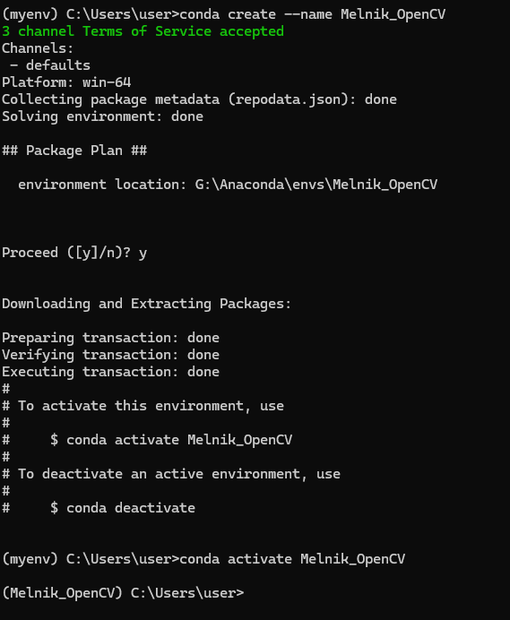

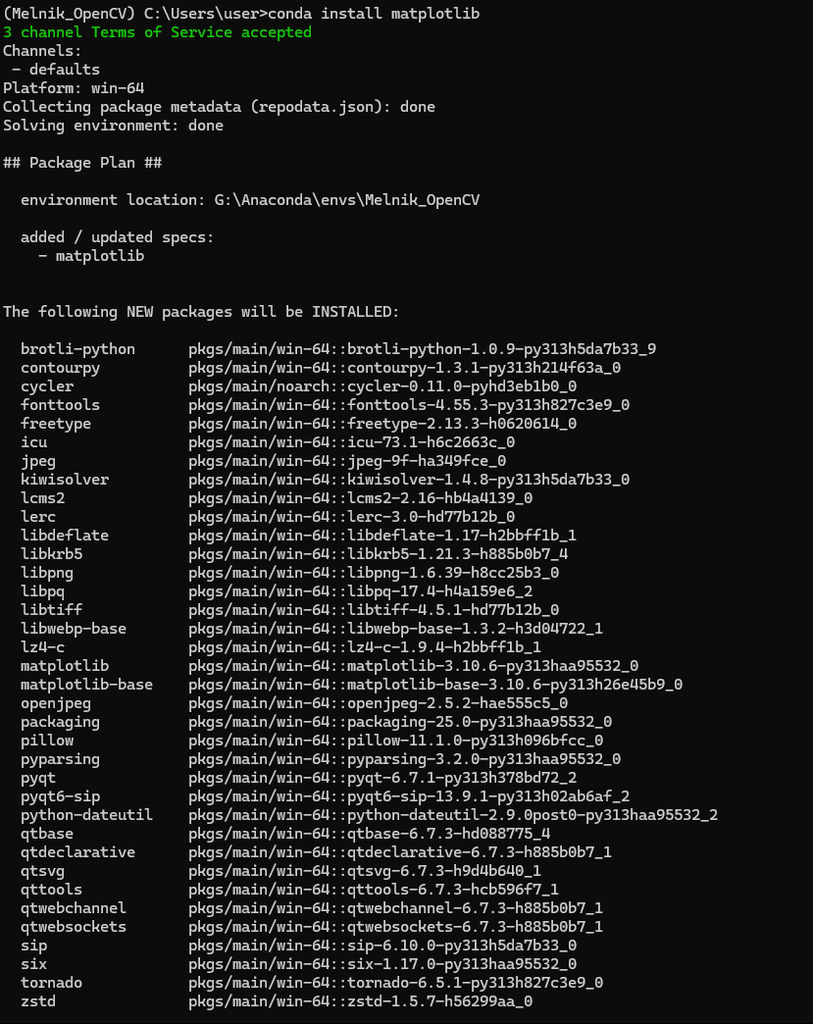

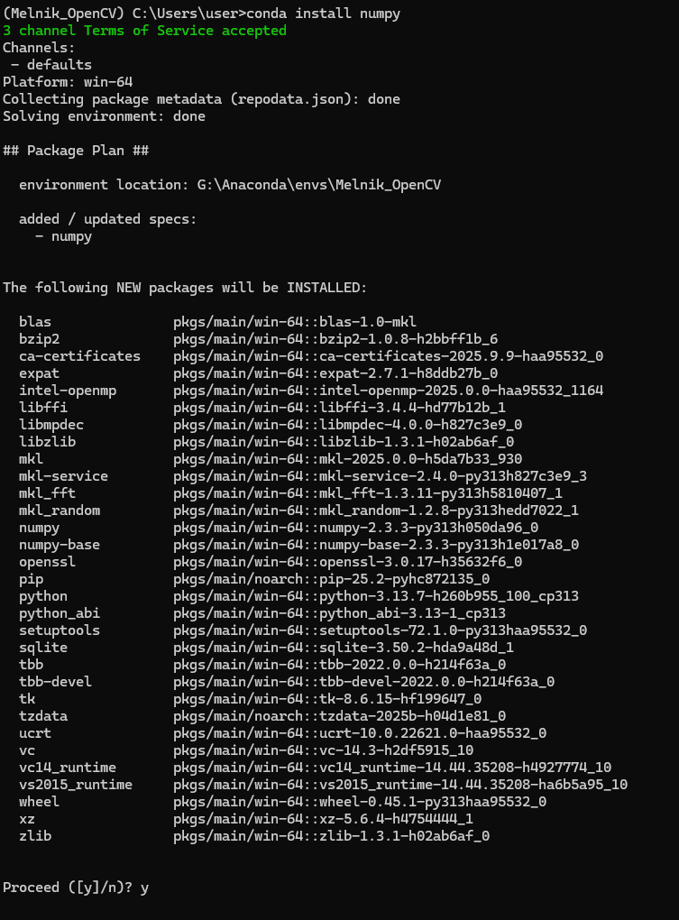

Контрольні питання:

1.Що таке pip і conda та чим вони відрізняються між собою?

Pip - це менеджер пакетів для Python, який встановлює бібліотеки з Python Package Index, тоді як conda - це менеджер пакетів та середовищ для багатьох мов, який встановлює бінарні пакети з власних каналів, як-от дистрибутив Anaconda. Основна відмінність полягає в тому, що conda може створювати ізольовані середовища з різними версіями Python, встановлювати пакети для інших мов, таких як R та Java, і встановлює вже скомпільовані бінарні файли, тоді як pip переважно орієнтований на Python і часто компілює пакети з вихідного коду під час встановлення.

2.Як виглядатиме виконання пунктів 1–3 індивідуального завдання за допомогою Virtualenv?

Базова версія Python містить у своєму складі інструмент для створення віртуальних середовищ Virtualenv. Conda включає власний менеджер середовища і надає деякі переваги щодо Virtualenv. Окрім того, середовища Conda повністю сумісні з базовими пакетами мови Python, які можуть бути встановлені за допомогою pip. Тому робота з Conda щодо цього є ефективнішою.

3.

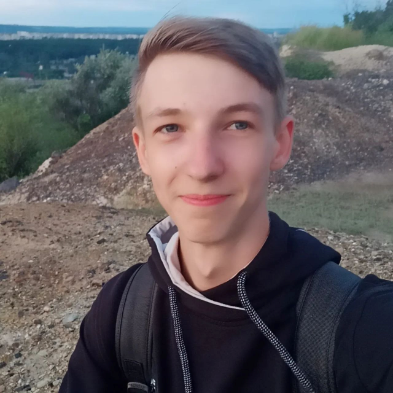

4.Написати процедуру на Python сортування масиву методом бульбашки.

```python
def bubble_sort(arr):
    n = len(arr)
    for i in range(n - 1):
        for j in range(0, n - i - 1):
            if arr[j] > arr[j + 1]:
                arr[j], arr[j + 1] = arr[j + 1], arr[j]
    return arr

numbers = [5, 2, 9, 1, 5, 6]
sorted_numbers = bubble_sort(numbers)
print(sorted_numbers)
```

```
[1, 2, 5, 5, 6, 9]
```

5.Як виконати компіляцію вхідного документа Jupyter Notebook з його середовища, не використовуючи інтерфейс командного рядка?

1.Через меню File У середовищі Jupyter Notebook:Відкрити свій .ipynb файл. У верхньому меню вибрати:File → Download as →

2.Через панель JupyterLab: Відкрити файл .ipynb. Вибрати у меню: File → Export Notebook As →

6.Як виконати компіляцію вхідного документа у Quarto?

В командний рядок написати команду: quarto render notebook.ipynb